# Exploring Marijuana

**Anonymous Student in CMSC320 Fall 2017**

## Personal Disclosure

I'd like to start this off with a disclosure: Although I am not and have never been a user of marijuana, I do believe that it should be legalized for a variety of reasons, some of which I will explain throughout this tutorial.

The purpose of this tutorial is to give you the tools you need to analyze data and explore trends. While I would like to use this data to advocate for marijuana legalization, note that this and most any data can be selectively manipulated for any purpose. My hope is that you, the reader, uses this power I will show you for good (creating information) and not for evil (creating misinformation). By giving you the sources of my data and methods of analysis, I am inviting you to go through the data yourself and see if you come to the same conclusions as I.

## Ethics

To get a visual sense for how data can be manipulated to show any sort of correlation, you might want to check out [this](http://www.tylervigen.com/spurious-correlations). It is a site which shows spurious correlations between variables which logically shouldn't have any bearing on each other, for example: the per capita cheese consumption is highly correlated with the number of people who died by becoming tangled in their bedsheets over time. These two datasets are highly unrelated, but the moral of the story is that if you seek for correlations, you will find them. Also see [this explained xkcd](https://www.explainxkcd.com/wiki/index.php/882:_Significant) on the ease in finding a correlation to back up your beliefs. If you need further background on pvalues to understand the xkcd comic, check out [this explanation here](https://www.statsdirect.com/help/basics/p_values.htm). For the comic, and for my project, the null hypothesis is that there is no correlation and the alternate hypothesis is that there is a correlation

In short: make sure to create a solid hypothesis to test out a potential correlation rather than wading through data to find a correlation that fits your story. In order to build a sensible hypothesis, it's critical to obtain domain knowledge or other words to learn the fundamentals of whatever you would like to research. Back to me, while I have not consumed marijuana, I do have some domain knowledge due to lengthy conversations with users and background research over the past several years.

Now that I've reviewed a bit about data ethics, let's get to it.

### Required Tools

You will need Python 3.5 and the following libraries:

- pandas
- re

I would also recommend using [Anaconda](https://www.continuum.io) to manage and install python libraries.

#### 1. Motivation for research

I propose that legalization of marijuana would be correlated with several positive effects:

- If marijuana is allowed out of the black market and into the streets, I hypothesize that this will weaken organized crime by cutting off a source of income. This is unfortunately not easy to prove in the short term, but I do predict that we will see this trend as time goes on
- Without the need to arrests marijuana users, I hypothesize that police will have more time to focus on harmful issues and that other crime will go down
- Marijuana has a generally calming effect on people, which I also believe can help reduce violent crime
- Marijuana can help people get off of addicted substances and back into a healthy balance

```python
import pandas as pd
import re
```

```python
# load in the baltimore arrest data
arrest_table = pd.read_csv("http://www.hcbravo.org/IntroDataSci/misc/BPD_Arrests.csv")
# display first 3 rows
arrest_table.head(3)
```

|  | arrest | age | sex | race | arrestDate | arrestTime | arrestLocation | incidentOffense | incidentLocation | charge | chargeDescription | district | post | neighborhood | Location 1 |
| --- | --- | --- | --- | --- | --- | --- | --- | --- | --- | --- | --- | --- | --- | --- | --- |
| 0 | 11126858.0 | 23 | B | M | 01/01/2011 | 00:00 | NaN | Unknown Offense | NaN | 3 0233 | Cds:P W/I Dist:Narc \|\| Cds:Poss W/Intent Dist:... | NaN | NaN | NaN | NaN |
| 1 | 11127013.0 | 37 | B | M | 01/01/2011 | 00:01 | 2000 Wilkens Ave | 79-Other | Wilkens Av & S Payson St | 1 1425 | Reckless Endangerment \|\| Hand Gun Violation | SOUTHERN | 934.0 | Carrollton Ridge | (39.2814026274, -76.6483635135) |
| 2 | 11126887.0 | 46 | B | M | 01/01/2011 | 00:01 | 2800 Mayfield Ave | Unknown Offense | NaN | NaN | Unknown Charge | NORTHEASTERN | 415.0 | Belair-Edison | (39.3227699160, -76.5735750473) |

Note that in this dataset, the sex and race columns were reversed. It's important to note that data is ultimately measured, collected, and synthesized by humans, even if it is done with technology built by humans, and there is always the chance for human or technology error. We would like to swap these two columns to get the correct result. In this dataset, there are two categories for sex: 'M' and 'F' for Male and Female and six for race, 'B', 'W', 'A', 'U', 'I', and 'H' for Black, White, Asian, Unknown, American Indian, and Hispanic.

```python
# swap the sex and race columns
arrest_table["race_new"] = arrest_table["sex"]
arrest_table["sex_new"] = arrest_table["race"]
arrest_table["race"] = arrest_table["race_new"]
arrest_table["sex"] = arrest_table["sex_new"]
arrest_table = arrest_table.drop('race_new', 1)
arrest_table = arrest_table.drop('sex_new', 1)
# display first 3 rows
arrest_table.head(3)
```

|  | arrest | age | sex | race | arrestDate | arrestTime | arrestLocation | incidentOffense | incidentLocation | charge | chargeDescription | district | post | neighborhood | Location 1 |
| --- | --- | --- | --- | --- | --- | --- | --- | --- | --- | --- | --- | --- | --- | --- | --- |
| 0 | 11126858.0 | 23 | M | B | 01/01/2011 | 00:00 | NaN | Unknown Offense | NaN | 3 0233 | Cds:P W/I Dist:Narc \|\| Cds:Poss W/Intent Dist:... | NaN | NaN | NaN | NaN |
| 1 | 11127013.0 | 37 | M | B | 01/01/2011 | 00:01 | 2000 Wilkens Ave | 79-Other | Wilkens Av & S Payson St | 1 1425 | Reckless Endangerment \|\| Hand Gun Violation | SOUTHERN | 934.0 | Carrollton Ridge | (39.2814026274, -76.6483635135) |
| 2 | 11126887.0 | 46 | M | B | 01/01/2011 | 00:01 | 2800 Mayfield Ave | Unknown Offense | NaN | NaN | Unknown Charge | NORTHEASTERN | 415.0 | Belair-Edison | (39.3227699160, -76.5735750473) |

The most important piece of data we would like to look at is the IncidentOffense column, as that will tell us what the reason for the arrest is. We would ideally like to drop any 'Unknown Offense' datapoints. However, we have no information on why these datapoints are missing. This data could have to do with particular police jurisdictions or police stations which did not properly record their data. It could also be particular offenses of crime for which there is no official category of Incident Offense which matches the crime.

```python
# print length of arrest table
total_length = len(arrest_table)
unknown_offense_length = len(arrest_table[
    arrest_table["incidentOffense"] == 'Unknown Offense'
])
# print number of arrests with 'Unknown Offense'
print(unknown_offense_length)
# print number of total arrests in 2015
print(total_length)
# print fraction of arrests which were of unknown offense
print(unknown_offense_length/total_length)
```

```
38649
104528
0.36974781876626356
```

#### 1.1 The issue of missing data

Missing data can fall into one of the following categories:

- Missing completely at random (MCAR)
  - Data is missing for entirely random reasons unrelated to the type of data stored. For example, if during a data transfer of unsorted data, an unreliable protocol was used and random datapoints were dropped, this could potentially be MCAR. If the data was actually MCAR, we could simply drop the datapoints and move on, but very few missing data are actually ever MCAR.
- Missing at random (MAR)
  - Data may be missing but we have a hunch for why it may be missing based on other observed data. For example, if we ask students their expected grade in a particular class this semester and their GPA, they may be willing to reveal their GPA but perhaps not all will reveal their grade in specific. If we have enough data on the relationship between GPA and grade and potentially other factors for the other students in the course, we may be able to estimate the grade based on the GPA even for those students who weren't forthcoming with the information
- Missing not at random (MNAR)
  - Data is neither MCAR nor MAR, but there is some relationship between why data is missing based on that type of data alone - for example, people involved in a long-term study on a medication for elderly people may die in the midst of the study and therefore will have missing data which can't necessarily be found solely from the other data collected

For more information on this, check out [this link](http://www.theanalysisfactor.com/missing-data-mechanism/).

#### 1.2 Dealing with the missing data

While I will not try to extrapolate for why the data was missing, or try to figure out what sort of crime data may even be entirely unreported, or not even recorded in this dataset, I will deal with this in a straightforward way.

If the data were to be missing completely at random, there would be a good chance that the percentage of marijuana arrests in the remaining data would hold for the entire dataset. This would be a sort of middle bound.

If the data missing is entirely made up of arrests having nothing to do with marijuana, that would be the lower bound. As in, if I divide the number of verifiably marijuana-related arrests by the number of arrests in total, this would be the minimum proportion of marijuana-related arrests possible in the dataset, since the assumption would be that none of the unknown datapoints were related to marijuana.

The upper bound would technically be if every single unknown arrest was for marijuana, but this would be highly unusual and highly unlikely. It is possible that there is a higher or lower proportion of marijuana arrests in the unknown data, but there's no way to know for certain without the ability to talk to the people involved in recording and preparing the data.

For the purposes of getting some sort of range for the true value, I will look at both the 'middle bound' and the 'lower bound'.

#### 1.3 Finding marijuana arrests - incident offense

First, let's check out the categories of 'incidentOffense' to see which ones may contain marijuana arrests

```python
arrest_table['incidentOffense'].unique()
```

```
array(['Unknown Offense', '79-Other', '81-Recovered Property',
       '54-Armed Person', '20A-Followup', '4E-Common Assault',
       '7A-Stolen Auto', '87-Narcotics', '4B-Agg. Asslt.- Cut',
       '75-Destruct. Of Property', '55-Disorderly Person',
       '4C-Agg. Asslt.- Oth.', '49-Family Disturbance',
       '4D-Agg. Asslt.- Hand', '3B-Robb Highway (Ua)',
       '6D-Larceny- From Auto', '5A-Burg. Res. (Force)',
       '111-Protective Order', '24-Towed Vehicle',
       '87O-Narcotics (Outside)', '29-Driving While Intox.',
       '6G-Larceny- From Bldg.', '97-Search & Seizure', '55A-Prostitution',
       '115-Trespassing', '5D-Burg. Oth. (Force)', '85-Mental Case',
       '5B-Burg. Res. (Att.)', '6J-Larceny- Other', '23-Unauthorized Use',
       '3JK-Robb Residence-Knife', '4F-Assault By Threat',
       '3LF-Robb Bank-Firearm', '6C-Larceny- Shoplifting',
       '4A-Agg. Asslt.- Gun', '61-Person Wanted On War', '8J-Arson Other',
       '109-Loitering', '6E-Larceny- Auto Acc', '3AF-Robb Hwy-Firearm',
       '88-Unfounded Call', '3K-Robb Res. (Ua)', '26-Recovered Vehicle',
       '56-Missing Person', '73-False Pretense', '3AK-Robb Hwy-Knife',
       '3JF-Robb Residence-Firearm', '5C-Burg. Res. (Noforce)',
       '5E-Burg. Oth. (Att.)', '52A-Animal Cruelty', '20H-Traffic Control',
       '2F-Placing Hands', '1A-Murder', '3JO-Robb Residence-Other Wpn',
       '2A-Rape (Force)', '3CK-Robb Comm-Knife', '80-Lost Property',
       '3AJF-Robb Carjack-Firearm', '6L-Larceny- From Locker',
       '71-Sex Offender Registry', '2D-Statutory Rape',
       '83-Discharging Firearm', '5F-Burg. Oth. (Noforce)',
       '3D-Robb Comm. (Ua)', '116-Public Urination / Defecation',
       '3CF-Robb Comm-Firearm', '6B-Larceny- Purse Snatch',
       '48-Involuntary Detention', '95-Exparte', '102-Questional Death',
       '3AJK-Robb Carjack-Knife', '98-Child Neglect',
       '3GF-Robb Conv Store-Firearm', '114-Hindering',
       '2G-Sodomy/Perverson', '103-Dead On Arrival', '96-Stop & Frisk',
       '112-Traffic Related Incident', '3P-Robb Misc. (Ua)', '78-Gambling',
       '3BJ-Robb Carjack(Ua)', '3CO-Robb Comm-Other Wpn',
       '67-Child Abuse-Physical', '2B-Rape (Attempt)', '2H-Indecent Exp.',
       '108-Liquor Law/Open Container', '3H-Robb Conv. Stor.(Ua)',
       '3NO-Robb Misc-Other Wpn', '117-Fto', '8AO-Arson Sin Res Str-Occ',
       '3NF-Robb Misc-Firearm', '3AO-Robb Hwy-Other Wpn', '84-Bomb Scare',
       '70A-Ill. Dumping', '13-Assist Officer', '76-Child Abuse-Sexual',
       '3LO-Robb Bank-Other Wpn', '7C-Stolen Veh./Other', '113-Littering',
       '3NK-Robb Misc-Knife', '2J-Other Sex Offn.', '58-Injured Person',
       '106-Custody Dispute', '20J-', '39-Fire', '6F-Larceny- Bicycle',
       '6H-Larceny- From Machine', '104-Malicious Burning',
       '8H-Arson Motor Veh', '60-Sick Person', '110-Summons Served',
       '93-Abduction - Other', '6A-Larceny- Pickpocket',
       '3GO-Robb Conv Store-Other Wpn', '8EO-Arson Oth Comm Str-Occ',
       '94-Abduction By Parent', '28-Suicide - Attempt',
       '59-Intoxicated Person', '3F-Robb Gas Sta. (Ua)',
       '64-Drug Free Zone', '6K-Larceny- Park. Meter',
       '3EK-Robb Gas Station-Knife', '2C-Carnal Knowledge',
       '3M-Robb Bank (Ua)', '3EF-Robb Gas Station-Firearm',
       '70-Sanitation Complaint', '8BO-Arson Oth Res Str-Occ',
       '8FO-Arson Public Str-Occ', '77-Dog Bite',
       '3GK-Robb Conv Store-Knife', '62-Person Lying On St.',
       '8I-Arson Other Mobile'], dtype=object)
```

The three which seem most promising based on the names would be '87-Narcotics', '87O-Narcotics (Outside)', and '23-Unauthorized Use'.

Let's filter out this data!

```python
# create a copy of the original data
arrest_table_drugs = arrest_table.copy()
# create a function which will return 'true' if the
# data falls under one of the categories mentioned above
def drug_related(category):
    return category == '87-Narcotics' \
        or category == '87O-Narcotics (Outside)' \
        or category == '23-Unauthorized Use'
# create a mask which only include these three categories
drug_mask = arrest_table_drugs.apply(
    lambda row: drug_related(row['incidentOffense']),
    axis = 1)
# use mask to filter the arrest_table_drugs data
arrest_table_drugs = arrest_table_drugs[drug_mask]
# print out first three rows of the data
arrest_table_drugs.head(5)
```

|  | arrest | age | sex | race | arrestDate | arrestTime | arrestLocation | incidentOffense | incidentLocation | charge | chargeDescription | district | post | neighborhood | Location 1 |
| --- | --- | --- | --- | --- | --- | --- | --- | --- | --- | --- | --- | --- | --- | --- | --- |
| 23 | 11126909.0 | 51 | M | B | 01/01/2011 | 01:02 | 2600 Harford Rd | 87-Narcotics | Harford Rd & Gorsuch Av | NaN | Unknown Charge | NORTHEASTERN | 411.0 | Coldstream Homestead Montebello | (39.3192761487, -76.5927562455) |
| 40 | 11126955.0 | 20 | M | B | 01/01/2011 | 02:20 | 900 Myrtle Ave | 87-Narcotics | 900 Myrtle Av | 1 0573 | Cds: Possession-Marihuana \|\| Possession Of Mar... | CENTRAL | 122.0 | Heritage Crossing | (39.2953767825, -76.6288329196) |
| 54 | 11127105.0 | 25 | M | W | 01/01/2011 | 10:15 | NaN | 87-Narcotics | 2500 Gatehouse Dr | 1 0233 | Cds Poss W/Int To Dist \|\| Cds Poss W/Int To Dist | NaN | NaN | NaN | NaN |
| 56 | 11127141.0 | 27 | M | B | 01/01/2011 | 12:45 | 2500 Edgecombe Cir | 87-Narcotics | 2500 Edgecombe Cr N #Apt J | 1 0573 | Cds: Possession-Marihuana \|\| Cds Violation | NORTHERN | 534.0 | Parklane | (39.3420471355, -76.6586011883) |
| 63 | 11127181.0 | 44 | M | W | 01/01/2011 | 16:01 | 300 S Catherine St | 87-Narcotics | 300 S Catherine St | 4 3550 | Cds:Possess-Not Marihuana \|\| Cds Violation | SOUTHWESTERN | 836.0 | Shipley Hill | (39.2838755357, -76.6559858034) |

#### 1.4 Finding marijuana arrests - charge description

The incident offense category is slightly broader than the scale we need to identify marijuana arrests - fortunately, the Baltimore crime data includes another category, 'chargeDescription'. That is where we'll be able to see whether or not the charge is due to marijuana.

Unfortunately, this is not straightforward. From the first five rows of data, we can already see several issues:

1) There is an 'Unknown Charge'. The missing data issue is prevalent at every level of data collection.

For the sake of getting on with the analysis, I will make the generous assumption that all 'Unknown Charge' data has nothing to do with marijuana. This will mean that the data I find within the incident offenses I have chosen can be thought of as a lower bound. I would like to show that there is overall a high proportion of marijuana arrests, so if I can show that using a lower bound number, then that does nothing to take from the weight of the argument

2) The charge description includes both 'Possession-Marihuana' and 'Possess-Not Marihuana', so figuring out which charges include marijuana is not as simple as just grabbing all data which contains marijuana

Further, this uses an awfully odd spelling of marijuana. On that note, it is important to check whether marijuana is also spelled elsewhere in the data with a 'j' or if it is spelled incorrectly. We can use regex to search through!

I propose that likely mistakes, other than switching out the j for h could involve incorrect vowels and extra 'n's. It is also possible that some may report marijuana as cannabis instead

```python
'''
matches() returns true if the regex matches the string
and false if it does not

It wraps the regex match call, since that does not
directly return a True/False value, but rather returns
a MatchObject instance if it matches or None if it does not

Further, it takes care of missing, or NaN values, whose type
is not string
'''
def matches(regex, string):
    if (type(string) != str):
        return False
    if (regex.match(string)):
        return True
    else:
        return False
```

```python
# regex which should capture cannabis and possible shortenings of the word
cannabis_regex = re.compile('.*can.*', re.IGNORECASE)
# mask which filters out everything which does not match regex
cannabis_mask = arrest_table_drugs.apply(
    lambda row: matches(cannabis_regex, row['chargeDescription']),
    axis = 1)
# filtered data table from drug table
cannabis_arrests = arrest_table_drugs[cannabis_mask]
# print out first five values of the table
cannabis_arrests.head()
```

|  | arrest | age | sex | race | arrestDate | arrestTime | arrestLocation | incidentOffense | incidentLocation | charge | chargeDescription | district | post | neighborhood | Location 1 |
| --- | --- | --- | --- | --- | --- | --- | --- | --- | --- | --- | --- | --- | --- | --- | --- |
| 18605 | 11217050.0 | 34 | M | B | 05/12/2011 | 19:40 | 6000 Westwood Ave | 87-Narcotics | 600 N Ellwood Av | 2A0696 | Att-Cds Manuf/Dist-Narc \|\| Poss Cocanie | NaN | NaN | NaN | NaN |
| 66854 | 12453981.0 | 35 | F | B | 04/05/2012 | 10:20 | 4400 Garrison Blvd | 87-Narcotics | 4400 Garrison Bd | 4 3550 | Cds:Possess-Not Marihuana \|\| Poss. Cocanie | NORTHWESTERN | 624.0 | Dolfield | (39.3368300621, -76.6847037102) |
| 103725 | 12607495.0 | 28 | M | B | 12/22/2012 | 00:30 | 3400 E Baltimore St | 87-Narcotics | 3400 E Baltimore St | 4 3550 | Cds:Possess-Not Marihuana \|\| Poss Cocanie | SOUTHEASTERN | 223.0 | Baltimore Highlands | (39.2925225518, -76.5691322119) |

From this preliminary search through the data, we can conclude that cannabis is not used as a term in the Baltimore crime dataset. There is a total of 3 charges in the categories which may include marijuana or cannabis crimes which include the string 'can', and all of these are mispellings of cocaine. Ironically, two of these include the string 'Marihuana', but they are prefixed with 'Not', and we will need to remove these sorts of data before analyzing.

```python
# regex which should capture most incorrect spellings of marijuana
marijuana_regex = re.compile('.*m.*r.*(j|h).*n+a.*', re.IGNORECASE)
# mask which filters out everything which does not match regex
marijuana_mask = arrest_table_drugs.apply(
    lambda row: matches(marijuana_regex, row['chargeDescription']),
    axis = 1)
# create filtered data table
marijuana_arrests = arrest_table_drugs[marijuana_mask]
# print out first five values of the table
marijuana_arrests.head()
```

|  | arrest | age | sex | race | arrestDate | arrestTime | arrestLocation | incidentOffense | incidentLocation | charge | chargeDescription | district | post | neighborhood | Location 1 |
| --- | --- | --- | --- | --- | --- | --- | --- | --- | --- | --- | --- | --- | --- | --- | --- |
| 40 | 11126955.0 | 20 | M | B | 01/01/2011 | 02:20 | 900 Myrtle Ave | 87-Narcotics | 900 Myrtle Av | 1 0573 | Cds: Possession-Marihuana \|\| Possession Of Mar... | CENTRAL | 122.0 | Heritage Crossing | (39.2953767825, -76.6288329196) |
| 56 | 11127141.0 | 27 | M | B | 01/01/2011 | 12:45 | 2500 Edgecombe Cir | 87-Narcotics | 2500 Edgecombe Cr N #Apt J | 1 0573 | Cds: Possession-Marihuana \|\| Cds Violation | NORTHERN | 534.0 | Parklane | (39.3420471355, -76.6586011883) |
| 63 | 11127181.0 | 44 | M | W | 01/01/2011 | 16:01 | 300 S Catherine St | 87-Narcotics | 300 S Catherine St | 4 3550 | Cds:Possess-Not Marihuana \|\| Cds Violation | SOUTHWESTERN | 836.0 | Shipley Hill | (39.2838755357, -76.6559858034) |
| 98 | 11127211.0 | 20 | M | B | 01/02/2011 | 00:55 | 1300 N Fulton Ave | 87O-Narcotics (Outside) | 1300 N Fulton Av | 1 0573 | Cds: Possession-Marihuana \|\| Cds | WESTERN | 724.0 | Sandtown-Winchester | (39.3032785775, -76.6461509215) |
| 120 | 11127343.0 | 37 | M | B | 01/02/2011 | 16:30 | 1500 N Wolfe Street St | 87-Narcotics | 1500 N Wolfe St | 4 3550 | Cds:Possess-Not Marihuana \|\| Cds Violation | EASTERN | 321.0 | Broadway East | (39.3077692503, -76.5914881683) |

Now we have narrowed the data to include charge descriptions which include marijuana of some spelling or mispelling. We need to next remove the 'Not's from the data:

```python
# regex which should capture most incorrect spellings of marijuana
marijuana_regex = re.compile('.*not m.*r.*(j|h).*n+a.*', re.IGNORECASE)
# mask which filters out everything which does not match regex
not_marijuana_mask = arrest_table_drugs.apply(
    lambda row: matches(marijuana_regex, row['chargeDescription']),
    axis = 1)
# create filtered data table based on broader 'marijuana arrests' table
marijuana_arrests = marijuana_arrests[~not_marijuana_mask]
# print out first five values of the table
marijuana_arrests.head()
```

|  | arrest | age | sex | race | arrestDate | arrestTime | arrestLocation | incidentOffense | incidentLocation | charge | chargeDescription | district | post | neighborhood | Location 1 |
| --- | --- | --- | --- | --- | --- | --- | --- | --- | --- | --- | --- | --- | --- | --- | --- |
| 40 | 11126955.0 | 20 | M | B | 01/01/2011 | 02:20 | 900 Myrtle Ave | 87-Narcotics | 900 Myrtle Av | 1 0573 | Cds: Possession-Marihuana \|\| Possession Of Mar... | CENTRAL | 122.0 | Heritage Crossing | (39.2953767825, -76.6288329196) |
| 56 | 11127141.0 | 27 | M | B | 01/01/2011 | 12:45 | 2500 Edgecombe Cir | 87-Narcotics | 2500 Edgecombe Cr N #Apt J | 1 0573 | Cds: Possession-Marihuana \|\| Cds Violation | NORTHERN | 534.0 | Parklane | (39.3420471355, -76.6586011883) |
| 98 | 11127211.0 | 20 | M | B | 01/02/2011 | 00:55 | 1300 N Fulton Ave | 87O-Narcotics (Outside) | 1300 N Fulton Av | 1 0573 | Cds: Possession-Marihuana \|\| Cds | WESTERN | 724.0 | Sandtown-Winchester | (39.3032785775, -76.6461509215) |
| 127 | 11127363.0 | 23 | M | B | 01/02/2011 | 20:00 | 2800 Mcelderry St | 87-Narcotics | 2800 Mc Elderry St | 1 0573 | Cds: Possession-Marihuana \|\| Pwid Marijuana | SOUTHEASTERN | 221.0 | McElderry Park | (39.2979297831, -76.5779346470) |
| 128 | 11127380.0 | 23 | F | B | 01/02/2011 | 20:30 | 2800 Mcelderry St | 87-Narcotics | 2800 Mc Elderry St | 1 0573 | Cds: Possession-Marihuana \|\| Poss Of Marijuana | SOUTHEASTERN | 221.0 | McElderry Park | (39.2979297831, -76.5779346470) |

#### 1.5 Examining marijuana data

Now that we have some data for marijuana arrests, let's take a look. First, let's check out the demographics within the data:

```python
# Racial demographics
print('Racial demographics\n')
total_marijuana_arrests = len(marijuana_arrests)
mj_arrests_B = len(marijuana_arrests[marijuana_arrests['race'] == 'B'])
print('black arrests: ', mj_arrests_B/total_marijuana_arrests)
mj_arrests_W = len(marijuana_arrests[marijuana_arrests['race'] == 'W'])
print('white arrests: ', mj_arrests_W/total_marijuana_arrests)
mj_arrests_A = len(marijuana_arrests[marijuana_arrests['race'] == 'A'])
print('asian arrests: ', mj_arrests_A/total_marijuana_arrests)
mj_arrests_I = len(marijuana_arrests[marijuana_arrests['race'] == 'I'])
print('indian arrests: ', mj_arrests_I/total_marijuana_arrests)
mj_arrests_H = len(marijuana_arrests[marijuana_arrests['race'] == 'H'])
print('hispanic arrests: ', mj_arrests_H/total_marijuana_arrests)
mj_arrests_U = len(marijuana_arrests[marijuana_arrests['race'] == 'U'])
print('unknown arrests: ', mj_arrests_U/total_marijuana_arrests)

# Gender demographics
print('\nGender demographics\n')
mj_arrests_M = len(marijuana_arrests[marijuana_arrests['sex'] == 'M'])
print('male arrests: ', mj_arrests_M/total_marijuana_arrests)
mj_arrests_F = len(marijuana_arrests[marijuana_arrests['sex'] == 'F'])
print('female arrests: ', mj_arrests_F/total_marijuana_arrests)
```

```
Racial demographics

black arrests:  0.9416111573688593
white arrests:  0.046523730224812654
asian arrests:  0.0021856786011656953
indian arrests:  0.00197751873438801
hispanic arrests:  0.0
unknown arrests:  0.007597835137385512

Gender demographics

male arrests:  0.9161115736885929
female arrests:  0.08378434637801832
```

It is pretty striking that 94% of people arrested for marijuana are black and 91% are male. One could ask several questions from this:

1) What are the total demographics of the city of Baltimore?

2) Do blacks or males use marijuana in much greater quantities than the rest of the population?

To answer the first question we can look at some data provided in visual format from the baltimore department of planning at this link and from a website called towncharts, whose Baltimore data can be found [here](http://www.towncharts.com/Maryland/Demographics/Baltimore-city-MD-Demographics-data.html).

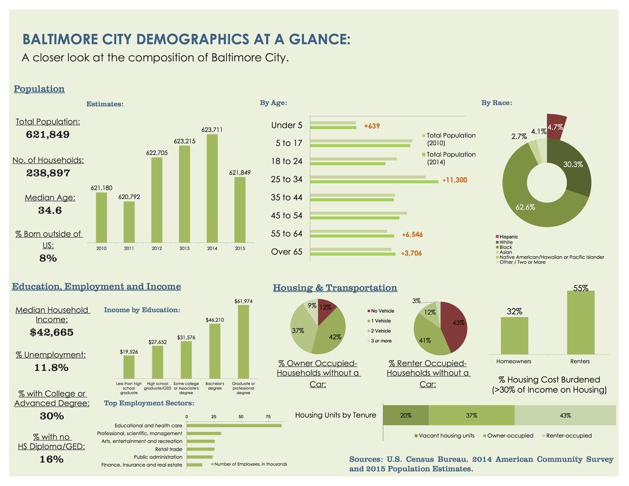

```python
from IPython.display import Image
Image(filename='Baltimore_Planning_Data.png')
```

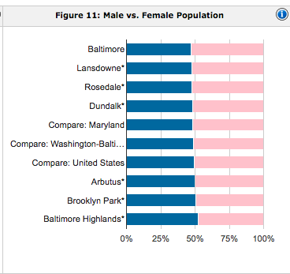

```python
Image(filename='Baltimore_Gender.png')
```

From the results of the data that the city of Baltimore has released, we can see that the population is approximately 63% black and slightly under 50% male. The arrest records would indicate that a disproportionately high number of blacks and a disproportionately high number of males are arrested for marijuana use.

This brings us to our second question - do blacks or males use marijuana significantly more than non-blacks and non-males?

Let's look at use by race, as provided by the [Brookings Institution](https://www.brookings.edu/blog/brookings-now/2017/08/11/charts-of-the-week-marijuana-use-by-race/), and use by gender, as collected by the [statista](https://www.statista.com/statistics/737757/share-americans-gender-marijuana/)

[figure not shown]

```python
Image(filename='Marijuana_Race.png')
```

[figure not shown]

```python
Image(filename='Marijuana_Gender.png')
```

This data shows a huge discrepancy. Assuming the national trend holds true for Baltimore, which would certainly be a large assumption, police are arresting blacks and males at a much higher rate than non-blacks and non-males for the same crimes.

This is not particularly shocking, given the high tensions between Baltimore residents and police that seems to regularly make its way to the news, but it does seem to be a huge issue.

Now, of course there are likely many confounding factors. For example, one of the many potential situations could be if there are a higher proportion of black residents in socioeconomically less off communities. This could mean lower income coming into the city, which might mean that police might have less funding and may need to be more aggresive with arrests to try and get more money flowing in. There could be countless logical or illogical reasons made up for why this may be, and each one would require proper data analysis along with likely going in and surveying people to collect data which is not yet publically out there.

#### 1.6 Examining likelihood for arrest, given use, by race

Let's take a look at the likelihood that one would be arrested for marijuana, given they are a user, based on race:

The probability that a black marijuana user is arrested can be broken down as follows

$P(B) = 0.63$ $P(User|B) = 0.16$ $P(B|Arrested For Marijuana) = 0.94$ $P(Arrested For Marijuana) = P(Arrested For Marijuana|Arrested) * P(Arrested)$ $= 0.1 * 100,000 / total population of baltimore = 10,000/ 620,000 = 0.016$ $P(Arrested For Marijuana|B) = P(B|Arrested For Marijuana) * P(Arrested For Marijuana) / P(B)$ $= 0.94 * 0.016 / 0.63 = 0.024$

2.4% of blacks in Baltimore are arrested for marijuana use

16% of blacks nationally use marijuana

That would mean that **approximately 15% of black marijuana users in Baltimore are arrested**

Let's take a look at the statistics for white users:

0.27% of whites in Baltimore are arrested for marijuana use

14% of whites nationally use marijuana

That would mean that **approximately 2% of white marijuana users in Baltimore are arrested**

That is a huge disparity - blacks are being arrested at a much higher rate than whites for the same crime in Baltimore

#### 1.6 What percent of arrests are made for Marijuana?

Now that we examined some demographic anomalies, which I would highly recommend further exploration of through surveys and other forms of gathering data, let's come back to the original question at hand.

```python
print('all arrests which involve marijuana, lower bound:',
    len(marijuana_arrests)/len(arrest_table))
print('all arrests which involve marijuana, middle bound:',
    len(marijuana_arrests)/(len(arrest_table) - unknown_offense_length))
print('drug arrests which involve marijuana:',
    len(marijuana_arrests)/len(arrest_table_drugs))
```

```
all arrests which involve marijuana, lower bound: 0.09191795499770397
all arrests which involve marijuana, middle bound: 0.14584313665963358
drug arrests which involve marijuana: 0.3065730695596682
```

The lower bound for arrests involving marijuana, which assumes that none of the missing data included any marijuana arrests, 9%, is a sizeable proportion of total arrests. This is crazy considering that this is for a substance which is [not pyschologically addictive](https://americanaddictioncenters.org/marijuana-rehab/is-it-addictive/), is [less](http://www.businessinsider.com/alcohol-marijuana-which-worse-health-2017-11/#all-things-considered-alcohols-effects-seem-markedly-more-extreme-and-riskier-than-marijuanas-10) [harmful](https://drugabuse.com/marijuana-vs-alcohol/) than alcohol, and is even medically legal in the state of Maryland.

If the data without known incident offenses is missing completely at random, that would bring the total arrests due to marijuana to about 15%.

Now let's examine a little bit of DC data to see if there is an effect on marijuana legalization on other crime

#### 2. Finding Data

State and Local Governments all over the United States are more and more often joining the trend of open sourcing their data for research purposes. Check out [this site](http://www.govtech.com/data/Are-Governments-Committed-to-Open-Data-Interactive-Map.html) for information on which jurisdictions may have open data.

#### 2.1 DC Crime Data

From the site I recommended, my first choice would be to take a look at DC crime data, since it is local and the jurisdiction has recently legalized marijuana.

We would like to explore the data, so we'll first need to download it. We'll be able to download the data in the form of a CSV, or comma-separated values, using pandas. First, we will download the latest data available, [Crime Incidents in 2017](http://opendata.dc.gov/datasets/crime-incidents-in-2017).

```python
# load our data into pandas dataframe
dc_crime_2017 = pd.read_csv('https://opendata.arcgis.com/datasets/6af5cb8dc38e4bcbac8168b27ee104aa_38.csv')
# print the columns that the data is using
print(dc_crime_2017.columns.values)
# print a random sampling of five rows from the csv
dc_crime_2017.sample(5)
```

```
['X' 'Y' 'CCN' 'REPORT_DAT' 'SHIFT' 'METHOD' 'OFFENSE' 'BLOCK' 'XBLOCK'
 'YBLOCK' 'WARD' 'ANC' 'DISTRICT' 'PSA' 'NEIGHBORHOOD_CLUSTER'
 'BLOCK_GROUP' 'CENSUS_TRACT' 'VOTING_PRECINCT' 'XCOORD' 'YCOORD'
 'LATITUDE' 'LONGITUDE' 'BID' 'START_DATE' 'END_DATE' 'OBJECTID']
```

|  | X | Y | CCN | REPORT_DAT | SHIFT | METHOD | OFFENSE | BLOCK | XBLOCK | YBLOCK | ... | CENSUS_TRACT | VOTING_PRECINCT | XCOORD | YCOORD | LATITUDE | LONGITUDE | BID | START_DATE | END_DATE | OBJECTID |
| --- | --- | --- | --- | --- | --- | --- | --- | --- | --- | --- | --- | --- | --- | --- | --- | --- | --- | --- | --- | --- | --- |
| 7673 | -76.927877 | 38.882155 | 17079162 | 2017-05-12T04:12:56.000Z | MIDNIGHT | OTHERS | MOTOR VEHICLE THEFT | 5100 - 5299 BLOCK OF E STREET SE | 406258.00 | 134926.0 | ... | 9905.0 | Precinct 104 | 406183.69 | 134963.96 | 38.882147 | -76.927875 | NaN | 2017-05-12T03:18:48.000Z | 2017-05-12T04:12:56.000Z | 100246160 |
| 30858 | -76.991121 | 38.934020 | 17164906 | 2017-09-22T22:25:40.000Z | EVENING | OTHERS | THEFT/OTHER | 3600 - 3699 BLOCK OF 12TH STREET NE | 400770.00 | 140681.0 | ... | 9301.0 | Precinct 68 | 400788.42 | 140658.24 | 38.934012 | -76.991119 | NaN | 2017-09-22T20:56:09.000Z | 2017-09-22T22:25:39.000Z | 100370055 |
| 24775 | -76.997101 | 38.932791 | 17195121 | 2017-11-10T15:39:25.000Z | EVENING | OTHERS | THEFT/OTHER | 600 - 699 BLOCK OF MICHIGAN AVENUE NE | 400251.53 | 140544.5 | ... | 9501.0 | Precinct 68 | 400185.38 | 140548.79 | 38.932783 | -76.997099 | NaN | 2017-11-10T09:30:17.000Z | 2017-11-10T11:30:22.000Z | 100355269 |
| 12379 | -76.984593 | 38.881267 | 17127281 | 2017-07-24T21:22:48.000Z | EVENING | OTHERS | THEFT F/AUTO | 1400 - 1499 BLOCK OF G STREET SE | 401337.00 | 134825.0 | ... | 6900.0 | Precinct 91 | 401341.03 | 134847.02 | 38.881259 | -76.984591 | NaN | 2017-07-24T18:45:05.000Z | 2017-07-24T19:30:18.000Z | 100250866 |
| 1871 | -76.999518 | 38.891483 | 17003813 | 2017-01-07T12:44:21.000Z | DAY | OTHERS | THEFT F/AUTO | 100 - 199 BLOCK OF 5TH STREET NE | 400042.00 | 135959.0 | ... | 8200.0 | Precinct 89 | 400020.85 | 135916.61 | 38.891475 | -76.999516 | NaN | 2017-01-07T11:30:00.000Z | 2017-01-07T12:44:04.000Z | 100240358 |

5 rows × 26 columns

The column which would be best in finding drug related crime would be the 'OFFENSE' column. If this is our first time looking at this dataset, we won't know what sort of offense categories the DC law enforcement may use in their recorded data. In order to assess which may be most helpful in narrowing down information to find data on marijuana use, we can print out which categories exist:

```python
dc_crime_2017['OFFENSE'].unique()
```

```
array(['THEFT/OTHER', 'THEFT F/AUTO', 'HOMICIDE', 'MOTOR VEHICLE THEFT',
       'BURGLARY', 'ASSAULT W/DANGEROUS WEAPON', 'ROBBERY', 'SEX ABUSE',
       'ARSON'], dtype=object)
```

This small step saves us what would have otherwise been a potentially long amount of time to wade through the data and find out exactly what is represented. It is clear that the data reported for DC crime activity does not include drug data based on the unique offense types in the dataset.

#### 2.2 DC Marijuana Data

The beautiful thing about data analysis is that there is so much data out there on such a large variety of topics that it can generally be assumed that if one source does not have everything needed to carry out an analysis, the requisit data will exist elsewhere. And if does not exist in a readily accessible form, it can be scraped from a website or even created based on other existing data if necessary.

DC would be ideal because marijuana was legalized recreationally effective February 2015 and it would have been interesting to observe the trends before and after legalization. Unfortunately, I found that the DC crime Data does not include drug crimes.

Not to despair, we can still look at the change in crimes in DC before and after the legalization of marijuana.

#### 2.3 DC Violent Crime Data

```python
# load our data into pandas dataframe
dc_crime_2014 = pd.read_csv('https://opendata.arcgis.com/datasets/6eaf3e9713de44d3aa103622d51053b5_9.csv')
# print first five rows from the csv
dc_crime_2014.head(5)
```

|  | X | Y | CCN | REPORT_DAT | SHIFT | METHOD | OFFENSE | BLOCK | XBLOCK | YBLOCK | ... | CENSUS_TRACT | VOTING_PRECINCT | XCOORD | YCOORD | LATITUDE | LONGITUDE | BID | START_DATE | END_DATE | OBJECTID |
| --- | --- | --- | --- | --- | --- | --- | --- | --- | --- | --- | --- | --- | --- | --- | --- | --- | --- | --- | --- | --- | --- |
| 0 | -77.020321 | 38.946317 | 13005683 | 2014-02-11T19:00:00.000Z | EVENING | OTHERS | ROBBERY | 500 - 599 BLOCK OF BUCHANAN STREET NW | 398238.64 | 142046.25 | ... | 2201.0 | Precinct 46 | 398317.17 | 142049.07 | 38.946310 | -77.020318 | NaN | 2013-01-13T18:30:00.000Z | 2013-01-13T18:35:00.000Z | 99812910 |
| 1 | -77.044150 | 38.925400 | 13046310 | 2014-02-19T21:15:00.000Z | EVENING | OTHERS | THEFT/OTHER | 1820 - 1899 BLOCK OF CLYDESDALE PLACE NW | 396171.79 | 139724.96 | ... | 3900.0 | Precinct 35 | 396204.85 | 139753.17 | 38.925392 | -77.044148 | NaN | 2013-04-10T14:00:00.000Z | 2013-04-10T14:05:00.000Z | 99816876 |
| 2 | -76.984899 | 38.907742 | 13141679 | 2014-04-11T00:00:00.000Z | MIDNIGHT | OTHERS | HOMICIDE | 1200 - 1299 BLOCK OF MEIGS PLACE NE | 401310.00 | 137764.00 | ... | 8804.0 | Precinct 78 | 401243.35 | 137823.65 | 38.907734 | -76.984896 | NaN | 2013-10-02T17:18:00.000Z | 2013-10-02T17:24:00.000Z | 99827980 |
| 3 | -76.987225 | 38.924048 | 13146221 | 2014-02-08T17:25:00.000Z | EVENING | OTHERS | THEFT/OTHER | 1300 - 1340 BLOCK OF RHODE ISLAND AVENUE NE | 401108.00 | 139574.00 | ... | 9102.0 | Precinct 72 | 401153.06 | 139528.55 | 38.924040 | -76.987222 | NaN | 2013-10-11T12:00:00.000Z | 2013-10-11T12:10:00.000Z | 99829147 |
| 4 | -77.037509 | 38.911133 | 13168199 | 2014-02-14T07:31:00.000Z | DAY | OTHERS | MOTOR VEHICLE THEFT | 1600 - 1699 BLOCK OF Q STREET NW | 396747.00 | 138141.00 | ... | 5301.0 | Precinct 15 | 396769.00 | 138113.38 | 38.911126 | -77.037507 | NaN | 2013-11-22T10:27:00.000Z | 2013-11-22T10:30:00.000Z | 99831757 |

5 rows × 26 columns

```python
# load our data into pandas dataframe
dc_crime_2015 = pd.read_csv('https://opendata.arcgis.com/datasets/35034fcb3b36499c84c94c069ab1a966_27.csv')
dc_crime_2016 = pd.read_csv('https://opendata.arcgis.com/datasets/bda20763840448b58f8383bae800a843_26.csv')
dc_crime_2013 = pd.read_csv('https://opendata.arcgis.com/datasets/5fa2e43557f7484d89aac9e1e76158c9_10.csv')
dc_crime_2012 = pd.read_csv('https://opendata.arcgis.com/datasets/010ac88c55b1409bb67c9270c8fc18b5_11.csv')
```

Let's take a sky-view look at the data, the total crime in the dataset as well as the total violent crime in 2014 and 2015:

```python
def isViolent(crime):
    return crime == 'HOMICIDE' \
        or crime == 'ASSAULT W/DANGEROUS WEAPON' \
        or crime == 'SEX ABUSE'

violent_crime_2012_mask = dc_crime_2012.apply(lambda row: isViolent(row['OFFENSE']), axis=1)
violent_crime_2013_mask = dc_crime_2013.apply(lambda row: isViolent(row['OFFENSE']), axis=1)
violent_crime_2014_mask = dc_crime_2014.apply(lambda row: isViolent(row['OFFENSE']), axis=1)
violent_crime_2015_mask = dc_crime_2015.apply(lambda row: isViolent(row['OFFENSE']), axis=1)
violent_crime_2016_mask = dc_crime_2016.apply(lambda row: isViolent(row['OFFENSE']), axis=1)
violent_crime_2012 = dc_crime_2012[violent_crime_2012_mask]
violent_crime_2013 = dc_crime_2013[violent_crime_2013_mask]
violent_crime_2014 = dc_crime_2014[violent_crime_2014_mask]
violent_crime_2015 = dc_crime_2015[violent_crime_2015_mask]
violent_crime_2016 = dc_crime_2016[violent_crime_2016_mask]
print('crime in 2012 totals', len(dc_crime_2012))
print('crime in 2013 totals', len(dc_crime_2013))
print('crime in 2014 totals', len(dc_crime_2014))
print('crime in 2015 totals', len(dc_crime_2015))
print('crime in 2016 totals', len(dc_crime_2016))
print('violent crime in 2012 totals', len(violent_crime_2012))
print('violent crime in 2013 totals', len(violent_crime_2013))
print('violent crime in 2014 totals', len(violent_crime_2014))
print('violent crime in 2015 totals', len(violent_crime_2015))
print('violent crime in 2016 totals', len(violent_crime_2016))
```

```
crime in 2012 totals 35274
crime in 2013 totals 35856
crime in 2014 totals 38408
crime in 2015 totals 37280
crime in 2016 totals 37200
violent crime in 2012 totals 2722
violent crime in 2013 totals 2794
violent crime in 2014 totals 2886
violent crime in 2015 totals 2878
violent crime in 2016 totals 2753
```

Interestingly enough, there is a barely perceptible difference in either overall crime reported or violent crime between 2014, when marijuana was illegal, and 2015, after legalization.

That being said, it can be seen from the data that both crime overall and violent crime had been rising from 2012 to 2014, and then had dropped between 2014 and 2015 and again between 2015 and 2016.

This is promising that there may be a positive effect on overall crime, but of course this should be verified with much more research on the topic. There are countless confounding variables which would make it very difficult to verifiably discern that the correlation may be explained in part by the legalization of marijuana

For some additional resources, check out the following:

[pandas documentation](https://pandas.pydata.org/pandas-docs/stable/index.html)

[re documentation](https://docs.python.org/3.5/library/re.html)

Substance Abuse and Mental Health Services Administration (SAMHSA)

[Population Data](https://www.samhsa.gov/data/population-data-nsduh/reports?tab=38)

- [Results from 2016 National Survey on Drug Use and Health](https://www.samhsa.gov/data/sites/default/files/NSDUH-DetTabs-2016/NSDUH-DetTabs-2016.htm)
- [Model-Based Prevalance Estimates of Drug Use](https://www.samhsa.gov/data/sites/default/files/NSDUHsaePercents2016/NSDUHsaePercents2016.pdf)

[Arrests, Usage, and Related Data for Marijuana in DC](https://www.drugscience.org/States/DC/DC.pdf)

[Marijuana as Medicine](https://www.drugabuse.gov/publications/drugfacts/marijuana-medicine)

[National Estimates of Marijuana Use and Related Indicators — National Survey on Drug Use and Health, United States, 2002–2014](https://www.cdc.gov/mmwr/volumes/65/ss/ss6511a1.htm)

To find data to do your own analysis on:

[Open Data In State and Local Governments](http://www.govtech.com/data/Are-Governments-Committed-to-Open-Data-Interactive-Map.html)

- [Chicago Open Data](https://data.cityofchicago.org/browse?category=Public%20Safety)
- [Chicago Crimes 2001 to present](https://data.cityofchicago.org/Public-Safety/Crimes-2001-to-present/ijzp-q8t2)
- [Raleigh Crimes 2005 - present](https://data.raleighnc.gov/Police/Police-Crime-Incident-Data-from-Jan-1-2005-Present/csw9-dd5k)
- [LA Crimes 2010 - present](https://data.lacity.org/A-Safe-City/Crime-Data-from-2010-to-Present/y8tr-7khq)
- [Austin crime data 2016](https://data.austintexas.gov/Public-Safety/2016-Annual-Crime-Data/8iue-zpf6) (does not include drug information)
- [Austin Crime Data broken down by type - 2010](https://data.austintexas.gov/Public-Safety/APD-Crime-Summary/d6z4-s3ex)
- [Montgomery County Crime Data July 2016-present](https://data.montgomerycountymd.gov/Public-Safety/Crime/icn6-v9z3)
- [NYC Crime Data Map](https://data.cityofnewyork.us/Public-Safety/crime/if3w-nb5w)
- [NYC Drug Crime Data](https://data.cityofnewyork.us/Public-Safety/Drug-Crime/v35q-aj2k)